# Multi-Sample Multi-condition Cell-Cell Communication Analysis via NicheNet: HNSCC application; All-vs-All

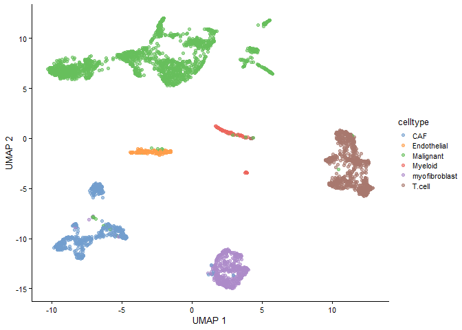

```r
scater::plotReducedDim(sce, dimred = "UMAP", colour_by = "celltype")
```

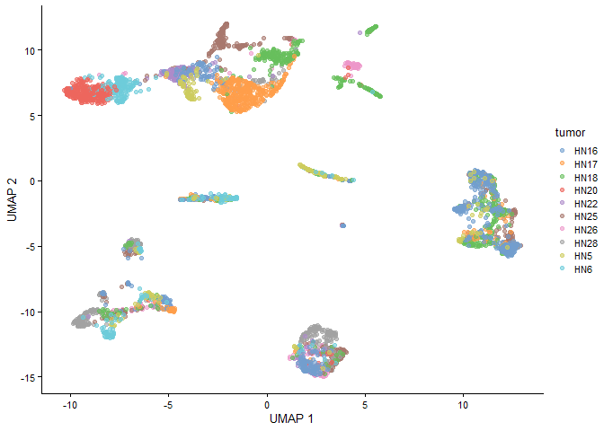

```r
scater::plotReducedDim(sce, dimred = "UMAP", colour_by = "tumor")
```

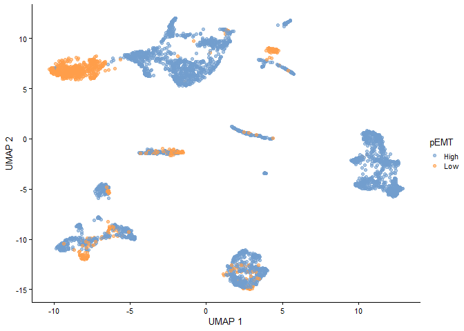

```r
scater::plotReducedDim(sce, dimred = "UMAP", colour_by = "pEMT")
```

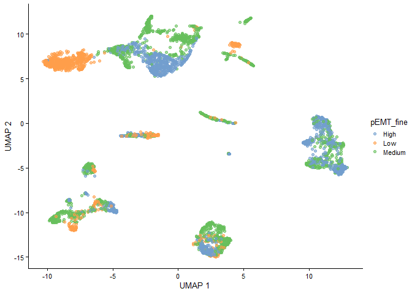

```r
scater::plotReducedDim(sce, dimred = "UMAP", colour_by = "pEMT_fine")
```

We will now also check the number of cells per cell type condition combination, and the number of patients per condition.

**User adaptation required**

```r
table(SummarizedExperiment::colData(sce)$celltype, SummarizedExperiment::colData(sce)$tumor) # cell types vs samples
##
##                 HN16 HN17 HN18 HN20 HN22 HN25 HN26 HN28 HN5 HN6
##   CAF             47   37   36    3    9   73   19  157  37  82
##   Endothelial     43   17   18    1    1    1    0   14  11  52
##   Malignant       82  353  263  331  123  153   61   49  70 157
##   Myeloid         15    2    7    0    1    8    1    1  58   6
##   myofibroblast   84    6   14   10   45   88   45  140   5   6
##   T.cell         300   61  207    0    0   93    3    0  28   0
table(SummarizedExperiment::colData(sce)$celltype, SummarizedExperiment::colData(sce)$pEMT) # cell types vs conditions
##
##                 High  Low
##   CAF            396  104
##   Endothelial    105   53
##   Malignant     1093  549
##   Myeloid         92    7
##   myofibroblast  382   61
##   T.cell         689    3
table(SummarizedExperiment::colData(sce)$tumor, SummarizedExperiment::colData(sce)$pEMT) # samples vs conditions
##
##        High Low
##   HN16  571   0
##   HN17  476   0
##   HN18  545   0
##   HN20    0 345
##   HN22  179   0
##   HN25  416   0
##   HN26    0 129
##   HN28  361   0
##   HN5   209   0
##   HN6     0 303
```

As you can see, some Celltype-Sample combinations have 0 cells. It is possible that during DE analysis, some cell types will be removed from the analysis if there is not enough information to do a DE analysis. (More info later)

## Step 0.3: Prepare settings of the MultiNicheNet cell-cell communication analysis

### Define in which metadata columns we can find the **group**, **sample** and **cell type** IDs

For the group_id, we now choose for the ‘pEMT’ column instead of ‘pEMT_fine’, which we will select in a subsequent analysis.

If you would have batches/covariates you can correct for (meaning: different covariate values should be present in all the groups of the group_id), we strongly recommend doing this, since this is one of the main unique possibilities of the MultiNicheNet approach.

**User adaptation required**

```r
sample_id = "tumor"
group_id = "pEMT"
celltype_id = "celltype"
covariates = NA
batches = NA
```

Sender and receiver cell types also need to be defined. Both are here all cell types in the dataset because we are interested in an All-vs-All analysis.

```r
senders_oi = SummarizedExperiment::colData(sce)[,celltype_id] %>% unique()
receivers_oi = SummarizedExperiment::colData(sce)[,celltype_id] %>% unique()
```

If the user wants it, it is possible to use only a subset of senders and receivers. Senders and receivers can be entirely different, but also overlapping, or the same. If you don’t use all the cell types in your data, we recommend to continue with a subset of your data.

Example code:

```r
subset_senders_receivers = FALSE
if(subset_senders_receivers == TRUE){
  senders_oi = SummarizedExperiment::colData(sce)[,celltype_id] %>% unique() %>% .[1:2]
  receivers_oi = SummarizedExperiment::colData(sce)[,celltype_id] %>% unique() %>% .[2:4]
  sce = sce[, SummarizedExperiment::colData(sce)[,celltype_id] %in% c(senders_oi, receivers_oi)]
}
```

Now we will go to the first real step of the MultiNicheNet analysis

# Step 1: Extract cell type abundance and expression information from receiver and sender cell types, and link this expression information for ligands of the sender cell types to the corresponding receptors of the receiver cell types

Since MultiNicheNet will infer group differences at the sample level for each cell type (currently via Muscat and pseudobulking), we need to have sufficient cells per sample of a cell type, and this for both groups. In the following analysis we will set this minimum number of cells per cell type per sample at 5. For 10x scRNAseq datasets, we recommend to set this to at least 20 (absolute minimum 10)

**User adaptation recommended**

```r
min_cells = 5
```

Now we will calculate abundance and expression information for each cell type / sample / group combination with the following functions. In the output of this function, you can also find some ‘Cell type abundance diagnostic plots’ that will the users which celltype-sample combinations will be left out later on for DE calculation because the nr of cells is lower than de defined minimum defined here above. If too many celltype-sample combinations don’t pass this threshold, we recommend to define your cell types in a more general way (use one level higher of the cell type ontology hierarchy) (eg TH17 CD4T cells –> CD4T cells).

```r
abundance_expression_info = get_abundance_expression_info(sce = sce, sample_id = sample_id, group_id = group_id, celltype_id = celltype_id, min_cells = min_cells, senders_oi = senders_oi, receivers_oi = receivers_oi, lr_network = lr_network, batches = batches)
```

Warning: means that some samples have a pseudobulk library size of 0 for a cell type (because that cell type was not present in that sample)

First, check the cell type abundance diagnostic plots.

### Interpretation of cell type abundance information

The first plot visualizes the number of cells per celltype-sample combination, and indicates which combinations are removed during the DE analysis because there are less than `min_cells` in the celltype-sample combination.

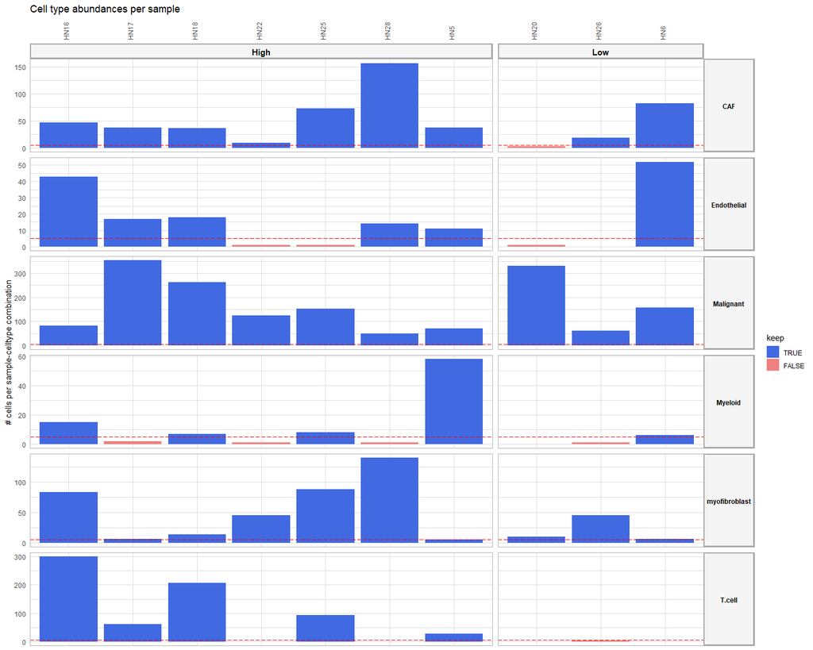

```r
abundance_expression_info$abund_plot_sample
```

In a next plot, we will look at differential abundance between the conditions. This because the pseudobulking approach behind Muscat could potentially suffer from some biases if there would be huge differences in abundances of a cell type between different groups. Downstream results of these cell types should then be considered with some caution.

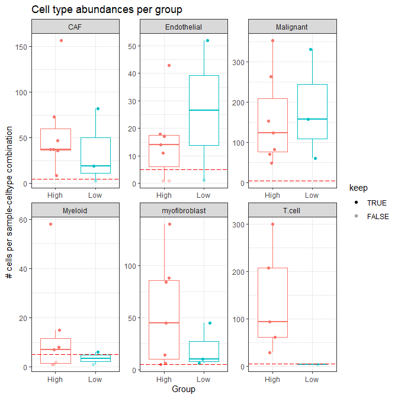

```r
abundance_expression_info$abund_plot_group
```

Differential abundance looks quite OK for the cell types kept for the DE analysis (i.e. CAF, Malignant and myofibroblast)

If you want to look at the cell numbers behind these plots, you can do so via the following piece of code

```r
abundance_expression_info$abundance_data_receiver
## # A tibble: 54 x 5
## # Groups:   sample, receiver [54]
##    sample receiver      n_cells_receiver group keep_receiver
##    <chr>  <chr>                    <int> <chr>         <dbl>
##  1 HN16   CAF                         47 High              1
##  2 HN16   Endothelial                 43 High              1
##  3 HN16   Malignant                   82 High              1
##  4 HN16   Myeloid                     15 High              1
##  5 HN16   myofibroblast               84 High              1
##  6 HN16   T.cell                     300 High              1
##  7 HN17   CAF                         37 High              1
##  8 HN17   Endothelial                 17 High              1
##  9 HN17   Malignant                  353 High              1
## 10 HN17   Myeloid                      2 High              0
## # ... with 44 more rows
abundance_expression_info$abundance_data_sender # in the case of an all-vs-all analysis: both are the same
## # A tibble: 54 x 5
## # Groups:   sample, sender [54]
##    sample sender        n_cells_sender group keep_sender
##    <chr>  <chr>                  <int> <chr>       <dbl>
##  1 HN16   CAF                       47 High            1
##  2 HN16   Endothelial               43 High            1
##  3 HN16   Malignant                 82 High            1
##  4 HN16   Myeloid                   15 High            1
##  5 HN16   myofibroblast             84 High            1
##  6 HN16   T.cell                   300 High            1
##  7 HN17   CAF                       37 High            1
##  8 HN17   Endothelial               17 High            1
##  9 HN17   Malignant                353 High            1
## 10 HN17   Myeloid                    2 High            0
## # ... with 44 more rows
```

**Important**: Based on the cell type abundance diagnostics, we recommend users to change their analysis settings if required, before proceeding with the rest of the analysis.

### Interpretation of expression information

Previously, we also calculated expression information. With the following piece of code, you can check the average expression for each gene per sample (normalized expression value and fraction of expressing cells with non-zero counts, and logCPM-pseudocounts).

```r
abundance_expression_info$celltype_info$avg_df
## # A tibble: 1,245,060 x 4
##    gene         sample average_sample celltype
##    <chr>        <chr>           <dbl> <fct>
##  1 C9orf152     HN28           0      myofibroblast
##  2 RPS11        HN28           5.78   myofibroblast
##  3 ELMO2        HN28           0.504  myofibroblast
##  4 CREB3L1      HN28           0      myofibroblast
##  5 PNMA1        HN28           1.17   myofibroblast
##  6 MMP2         HN28           0.103  myofibroblast
##  7 TMEM216      HN28           0.167  myofibroblast
##  8 TRAF3IP2.AS1 HN28           0.767  myofibroblast
##  9 LRRC37A5P    HN28           0      myofibroblast
## 10 LOC653712    HN28           0.0757 myofibroblast
## # ... with 1,245,050 more rows
abundance_expression_info$celltype_info$frq_df
## # A tibble: 1,245,060 x 4
##    gene         sample fraction_sample celltype
##    <chr>        <chr>            <dbl> <chr>
##  1 C9orf152     HN28            0      myofibroblast
##  2 RPS11        HN28            0.957  myofibroblast
##  3 ELMO2        HN28            0.157  myofibroblast
##  4 CREB3L1      HN28            0      myofibroblast
##  5 PNMA1        HN28            0.243  myofibroblast
##  6 MMP2         HN28            0.05   myofibroblast
##  7 TMEM216      HN28            0.0429 myofibroblast
##  8 TRAF3IP2.AS1 HN28            0.593  myofibroblast
##  9 LRRC37A5P    HN28            0      myofibroblast
## 10 LOC653712    HN28            0.0929 myofibroblast
## # ... with 1,245,050 more rows
abundance_expression_info$celltype_info$pb_df
## # A tibble: 1,120,554 x 4
##    gene         sample pb_sample celltype
##    <chr>        <chr>      <dbl> <fct>
##  1 C9orf152     HN16        0    myofibroblast
##  2 RPS11        HN16        9.14 myofibroblast
##  3 ELMO2        HN16        6.13 myofibroblast
##  4 CREB3L1      HN16        0    myofibroblast
##  5 PNMA1        HN16        6.28 myofibroblast
##  6 MMP2         HN16        1.67 myofibroblast
##  7 TMEM216      HN16        3.29 myofibroblast
##  8 TRAF3IP2.AS1 HN16        6.20 myofibroblast
##  9 LRRC37A5P    HN16        0    myofibroblast
## 10 LOC653712    HN16        3.92 myofibroblast
## # ... with 1,120,544 more rows
```

Now for the average per group:

```r
abundance_expression_info$celltype_info$avg_df_group
## # A tibble: 249,012 x 4
## # Groups:   group, celltype [12]
##    group celltype gene     average_group
##    <chr> <fct>    <chr>            <dbl>
##  1 High  CAF      A1BG           0.211
##  2 High  CAF      A1BG.AS1       0.124
##  3 High  CAF      A1CF           0.00428
##  4 High  CAF      A2M            2.68
##  5 High  CAF      A2M.AS1        0.0882
##  6 High  CAF      A2ML1          0.0265
##  7 High  CAF      A2MP1          0
##  8 High  CAF      A4GALT         0.609
##  9 High  CAF      A4GNT          0.00193
## 10 High  CAF      AAAS           0.458
## # ... with 249,002 more rows
abundance_expression_info$celltype_info$frq_df_group
## # A tibble: 249,012 x 4
## # Groups:   group, celltype [12]
##    group celltype gene     fraction_group
##    <chr> <chr>    <chr>             <dbl>
##  1 High  CAF      A1BG            0.103
##  2 High  CAF      A1BG.AS1        0.0536
##  3 High  CAF      A1CF            0.0739
##  4 High  CAF      A2M             0.500
##  5 High  CAF      A2M.AS1         0.0447
##  6 High  CAF      A2ML1           0.207
##  7 High  CAF      A2MP1           0
##  8 High  CAF      A4GALT          0.215
##  9 High  CAF      A4GNT           0.00386
## 10 High  CAF      AAAS            0.115
## # ... with 249,002 more rows
abundance_expression_info$celltype_info$pb_df_group
## # A tibble: 249,012 x 4
## # Groups:   group, celltype [12]
##    group celltype gene     pb_group
##    <chr> <fct>    <chr>       <dbl>
##  1 High  CAF      A1BG        3.86
##  2 High  CAF      A1BG.AS1    2.99
##  3 High  CAF      A1CF        0.527
##  4 High  CAF      A2M         7.99
##  5 High  CAF      A2M.AS1     2.55
##  6 High  CAF      A2ML1       1.92
##  7 High  CAF      A2MP1       0
##  8 High  CAF      A4GALT      5.61
##  9 High  CAF      A4GNT       0.157
## 10 High  CAF      AAAS        4.84
## # ... with 249,002 more rows
```

In the last part of this step, we combined this information for each ligand-receptor pair combination for each sender-receiver combination. The output of this can be seen as well:

For sample-based:

```r
abundance_expression_info$sender_receiver_info$avg_df
## # A tibble: 1,619,640 x 8
##    sample sender    receiver ligand  receptor avg_ligand avg_receptor ligand_receptor_prod
##    <chr>  <fct>     <fct>    <chr>   <chr>         <dbl>        <dbl>                <dbl>
##  1 HN17   Myeloid   Myeloid  HLA.DMA CD74           8.76        12.5                 110.
##  2 HN17   Malignant Myeloid  MIF     CD74           8.40        12.5                 105.
##  3 HN16   Malignant Myeloid  MIF     CD74           8.61        11.9                 102.
##  4 HN18   Myeloid   Myeloid  HLA.DMA CD74           7.78        12.6                  98.3
##  5 HN5    Myeloid   Myeloid  HLA.DMA CD74           7.76        12.2                  94.5
##  6 HN26   Myeloid   Myeloid  CCL19   CCR7           8.16        11.5                  94.2
##  7 HN5    Malignant Myeloid  MIF     CD74           7.72        12.2                  93.9
##  8 HN5    Myeloid   CAF      HLA.DRA CD63          11.2          8.15                 90.9
##  9 HN18   Malignant Myeloid  MIF     CD74           7.20        12.6                  90.9
## 10 HN5    Myeloid   Myeloid  HLA.DMB CD74           7.38        12.2                  89.8
## # ... with 1,619,630 more rows
abundance_expression_info$sender_receiver_info$frq_df
## # A tibble: 1,619,640 x 8
##    sample sender        receiver    ligand receptor fraction_ligand fraction_receptor ligand_receptor_fraction_prod
##    <chr>  <chr>         <chr>       <chr>  <chr>              <dbl>             <dbl>                         <dbl>
##  1 HN28   myofibroblast Myeloid     B2M    TAP1                   1                 1                             1
##  2 HN28   myofibroblast Myeloid     B2M    TAP2                   1                 1                             1
##  3 HN28   myofibroblast Myeloid     B2M    LILRB1                 1                 1                             1
##  4 HN28   myofibroblast Myeloid     B2M    KLRD1                  1                 1                             1
##  5 HN28   myofibroblast Myeloid     HLA.C  LILRB1                 1                 1                             1
##  6 HN28   myofibroblast Myeloid     HLA.C  LILRB2                 1                 1                             1
##  7 HN28   myofibroblast Myeloid     HLA.B  LILRB1                 1                 1                             1
##  8 HN28   myofibroblast Myeloid     HLA.B  KLRD1                  1                 1                             1
##  9 HN28   myofibroblast Myeloid     HLA.B  LILRB2                 1                 1                             1
## 10 HN25   myofibroblast Endothelial B2M    TAP1                   1                 1                             1
## # ... with 1,619,630 more rows
abundance_expression_info$sender_receiver_info$pb_df
## # A tibble: 1,331,704 x 8
##    sample sender  receiver ligand  receptor pb_ligand pb_receptor ligand_receptor_pb_prod
##    <chr>  <fct>   <fct>    <chr>   <chr>        <dbl>       <dbl>                   <dbl>
##  1 HN5    Myeloid Myeloid  HLA.DMA CD74         10.2        10.8                     111.
##  2 HN5    Myeloid Myeloid  HLA.DMB CD74         10.1        10.8                     110.
##  3 HN18   Myeloid Myeloid  HLA.DMA CD74         10.1        10.8                     109.
##  4 HN5    Myeloid Myeloid  HLA.DRA CD63         10.7        10.1                     108.
##  5 HN17   Myeloid Myeloid  HLA.DMA CD74         10.1        10.6                     107.
##  6 HN5    Myeloid Myeloid  MIF     CD74          9.75       10.8                     106.
##  7 HN5    Myeloid Myeloid  HLA.DRA CD53         10.7         9.86                    106.
##  8 HN17   CAF     Myeloid  MIF     CD74          9.94       10.6                     105.
##  9 HN5    T.cell  Myeloid  MIF     CD74          9.70       10.8                     105.
## 10 HN18   Myeloid Myeloid  HLA.DMB CD74          9.71       10.8                     105.
## # ... with 1,331,694 more rows
```

For group-based:

```r
abundance_expression_info$sender_receiver_info$avg_df_group
## # A tibble: 323,928 x 8
## # Groups:   group, sender [12]
##    group sender        receiver    ligand   receptor avg_ligand_group avg_receptor_group ligand_receptor_prod_group
##    <chr> <fct>         <fct>       <chr>    <chr>               <dbl>              <dbl>                      <dbl>
##  1 High  Malignant     Myeloid     MIF      CD74                 7.67              11.5                        88.3
##  2 High  Endothelial   Myeloid     MIF      CD74                 6.16              11.5                        71.0
##  3 High  Malignant     Endothelial MIF      CD74                 7.67               8.91                       68.3
##  4 High  CAF           Myeloid     MIF      CD74                 5.85              11.5                        67.3
##  5 High  Myeloid       CAF         HLA.DRA  CD63                 8.58               7.47                       64.1
##  6 High  Myeloid       Myeloid     HLA.DMA  CD74                 5.46              11.5                        62.8
##  7 Low   CAF           CAF         SERPING1 C1R                  7.73               8.04                       62.1
##  8 High  myofibroblast Myeloid     MIF      CD74                 5.35              11.5                        61.7
##  9 Low   Malignant     Myeloid     MIF      CD74                 7.47               7.60                       56.8
## 10 High  myofibroblast CAF         SERPING1 C1R                  7.72               7.36                       56.8
## # ... with 323,918 more rows
abundance_expression_info$sender_receiver_info$frq_df_group
## # A tibble: 323,928 x 8
## # Groups:   group, sender [12]
##    group sender        receiver    ligand   receptor fraction_ligand_group fraction_receptor_group ligand_receptor_fraction_prod_group
##    <chr> <chr>         <chr>       <chr>    <chr>                    <dbl>                   <dbl>                               <dbl>
##  1 High  Endothelial   Endothelial PECAM1   PECAM1                   1                       1                                   1
##  2 Low   CAF           CAF         SERPING1 C1R                      0.992                   0.996                               0.988
##  3 High  Malignant     Myeloid     MIF      CD74                     0.986                   1                                   0.986
##  4 Low   myofibroblast CAF         SERPING1 C1R                      0.970                   0.996                               0.966
##  5 High  Malignant     Endothelial MIF      CD74                     0.986                   0.969                               0.956
##  6 High  CAF           Myeloid     B2M      KLRD1                    1                       0.956                               0.956
##  7 High  Endothelial   Myeloid     B2M      KLRD1                    1                       0.956                               0.956
##  8 High  Endothelial   Myeloid     HLA.B    KLRD1                    1                       0.956                               0.956
##  9 High  Endothelial   Myeloid     HLA.E    KLRD1                    1                       0.956                               0.956
## 10 High  Malignant     Myeloid     B2M      KLRD1                    1                       0.956                               0.956
## # ... with 323,918 more rows
abundance_expression_info$sender_receiver_info$pb_df_group
## # A tibble: 323,928 x 8
## # Groups:   group, sender [12]
##    group sender        receiver      ligand   receptor pb_ligand_group pb_receptor_group ligand_receptor_pb_prod_group
##    <chr> <fct>         <fct>         <chr>    <chr>              <dbl>             <dbl>                         <dbl>
##  1 High  T.cell        Myeloid       MIF      CD74                9.33             10.4                           96.8
##  2 High  myofibroblast Myeloid       MIF      CD74                9.32             10.4                           96.7
##  3 High  CAF           Myeloid       MIF      CD74                9.30             10.4                           96.5
##  4 High  Malignant     Myeloid       MIF      CD74                9.24             10.4                           96.0
##  5 High  myofibroblast T.cell        LGALS1   PTPRC               9.74              9.83                          95.8
##  6 Low   myofibroblast T.cell        MIF      CXCR4               9.37             10.2                           95.7
##  7 High  CAF           T.cell        LGALS1   PTPRC               9.69              9.83                          95.3
##  8 High  T.cell        T.cell        HMGB1    CXCR4               9.43             10.1                           95.2
##  9 High  myofibroblast CAF           SERPING1 C1R                 9.84              9.66                          95.1
## 10 High  myofibroblast myofibroblast SERPING1 C1R                 9.84              9.65                          95.0
## # ... with 323,918 more rows
```

# Step 2: Perform genome-wide differential expression analysis of receiver and sender cell types to define DE genes between the conditions of interest. Based on this analysis, we can define the logFC/p-value of ligands in senders and receptors in receivers, and define the set of affected target genes in the receiver.

Now we will go over to the multi-group, multi-sample differential expression (DE) analysis (also called ‘differential state’ analysis by the developers of Muscat).

### Define the contrasts and covariates of interest for the DE analysis.

Here, we want to compare the p-EMT-high vs the p-EMT-low group and find cell-cell communication events that are higher in high than low pEMT.

Note the format to indicate the contrasts! (This formatting should be adhered to very strictly, and white spaces are not allowed)

**User adaptation required**

```r
contrasts_oi = c("'High-Low','Low-High'")
contrast_tbl = tibble(contrast =
                        c("High-Low","Low-High"),
                      group = c("High","Low"))
```

### Perform the DE analysis for each cell type.

```r
DE_info = get_DE_info(sce = sce, sample_id = sample_id, group_id = group_id, celltype_id = celltype_id, batches = batches, covariates = covariates, contrasts_oi = contrasts_oi, min_cells = min_cells)
## [1] "excluded cell types are:"
## [1] "Endothelial" "Myeloid"     "T.cell"
## [1] "These celltypes are not considered in the analysis. After removing samples that contain less cells than the required minimal, some groups don't have 2 or more samples anymore. As a result the analysis cannot be run. To solve this: decrease the number of min_cells or change your group_id and pool all samples that belong to groups that are not of interest! "
```

### Check DE results

Table with logFC and p-values for each gene-celltype-contrast:

```r
DE_info$celltype_de$de_output_tidy
## # A tibble: 64,162 x 9
##    gene         cluster_id   logFC logCPM      F  p_val p_adj.loc p_adj contrast
##    <chr>        <chr>        <dbl>  <dbl>  <dbl>  <dbl>     <dbl> <dbl> <chr>
##  1 RPS11        CAF        -0.0666   9.29 0.0658 0.801          1 0.984 High-Low
##  2 ELMO2        CAF         0.726    6.64 2.31   0.149          1 0.743 High-Low
##  3 CREB3L1      CAF         0.149    5.44 0.0184 0.894          1 0.994 High-Low
##  4 PNMA1        CAF        -1.04     6.51 4.03   0.0634         1 0.573 High-Low
##  5 MMP2         CAF         0.162    9.28 0.422  0.526          1 0.951 High-Low
##  6 TMEM216      CAF        -1.34     6    5.85   0.0291         1 0.442 High-Low
##  7 TRAF3IP2.AS1 CAF        -0.496    5.54 0.718  0.41           1 0.924 High-Low
##  8 ZHX3         CAF        -0.207    5.46 0.103  0.753          1 0.979 High-Low
##  9 ERCC5        CAF         0.202    6.08 0.0925 0.765          1 0.982 High-Low
## 10 APBB2        CAF        -0.235    6.47 0.249  0.625          1 0.966 High-Low
## # ... with 64,152 more rows
```

Diagnostic p-value histograms:

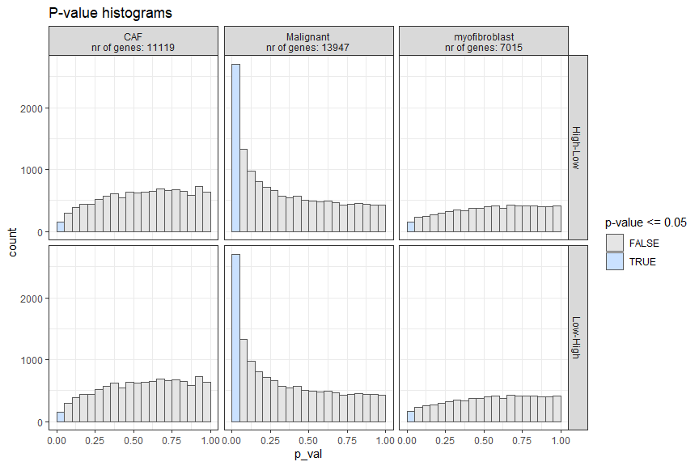

```r
DE_info$hist_pvals
```

(Note: this p-value histograms are the same for High-Low and Low-High because we only have two groups and compare them to each other - a DE gene in one comparison will then also be DE in the other comparison, with just a reversed sign of the logFC)

In order to trust the p-values, the p-value distributions should be uniform distributions, with a peak allowed between 0 and 0.05 if there would be a clear biological effect in the data. This clear effect (=clear DE) seems to be present here in the Malignant cell type populations, although the histogram is not very uniformly distributed for p-values between 0.05 and 0.25. This might point to issues in the DE model definition (eg we did not add all important covariates, substructure present,…)

### Empirical Null procedure

**User adaptation recommended**

```r
empirical_pval = TRUE
if(empirical_pval == TRUE){
  DE_info_emp = get_empirical_pvals(DE_info$celltype_de$de_output_tidy)
}
```

Table with logFC and p-values for each gene-celltype-contrast:

```r
DE_info_emp$de_output_tidy_emp
## # A tibble: 64,162 x 11
##    gene         cluster_id   logFC logCPM      F  p_val p_adj.loc p_adj contrast   p_emp p_adj_emp
##    <chr>        <chr>        <dbl>  <dbl>  <dbl>  <dbl>     <dbl> <dbl> <chr>      <dbl>     <dbl>
##  1 RPS11        CAF        -0.0666   9.29 0.0658 0.801          1 0.984 High-Low 0.748       0.991
##  2 ELMO2        CAF         0.726    6.64 2.31   0.149          1 0.743 High-Low 0.0864      0.991
##  3 CREB3L1      CAF         0.149    5.44 0.0184 0.894          1 0.994 High-Low 0.887       0.998
##  4 PNMA1        CAF        -1.04     6.51 4.03   0.0634         1 0.573 High-Low 0.0246      0.991
##  5 MMP2         CAF         0.162    9.28 0.422  0.526          1 0.951 High-Low 0.457       0.991
##  6 TMEM216      CAF        -1.34     6    5.85   0.0291         1 0.442 High-Low 0.00834     0.991
##  7 TRAF3IP2.AS1 CAF        -0.496    5.54 0.718  0.41           1 0.924 High-Low 0.314       0.991
##  8 ZHX3         CAF        -0.207    5.46 0.103  0.753          1 0.979 High-Low 0.692       0.991
##  9 ERCC5        CAF         0.202    6.08 0.0925 0.765          1 0.982 High-Low 0.733       0.991
## 10 APBB2        CAF        -0.235    6.47 0.249  0.625          1 0.966 High-Low 0.545       0.991
## # ... with 64,152 more rows
```

The following plot shows those corrected, empirical p-values:

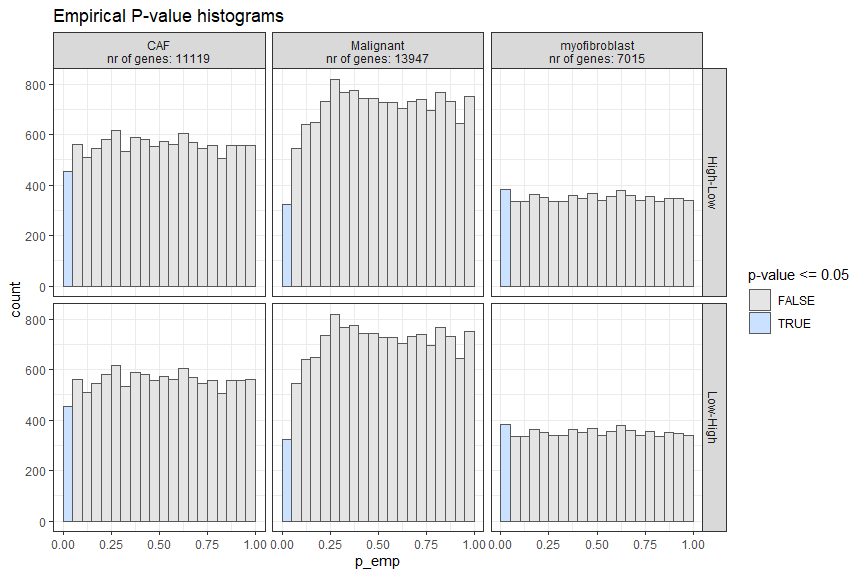

```r
DE_info_emp$hist_pvals_emp
```

The following plots show how well the correction worked. The green fitted curve should fit well with the histogram. If not, this might point to some issues in the DE model definition.

**User adaptation required**

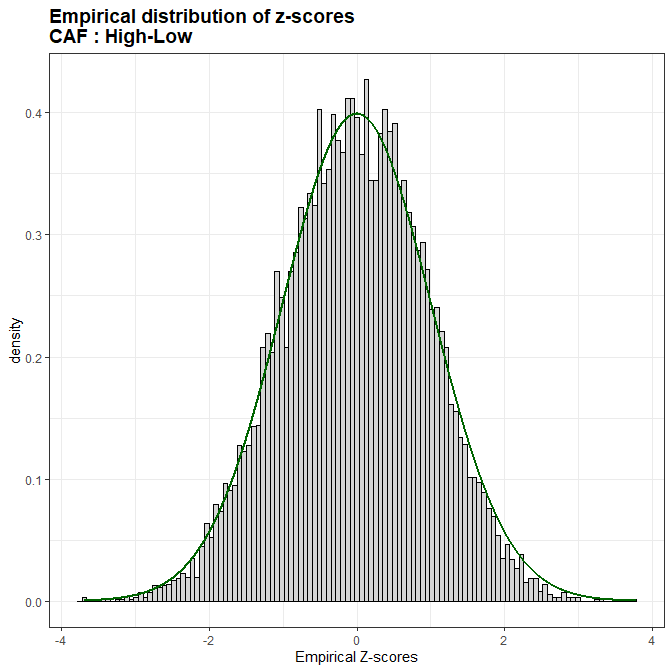

```
##
## $`CAF.Low-High`
```

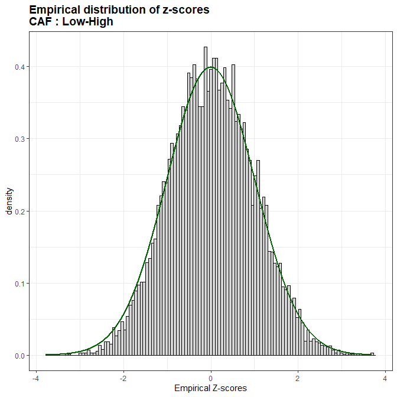

```
##
## $`Malignant.High-Low`
```

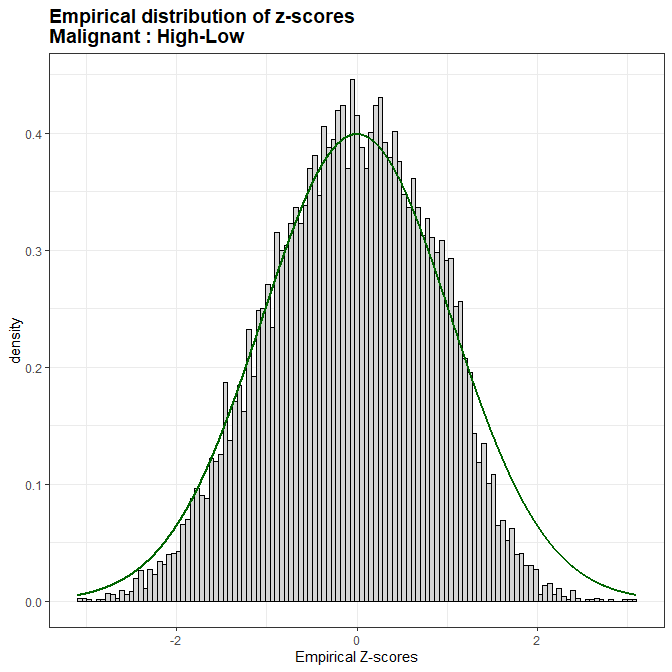

```
##
## $`Malignant.Low-High`
```

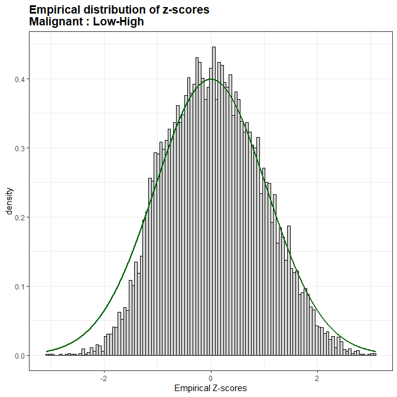

```
##
## $`myofibroblast.High-Low`
```

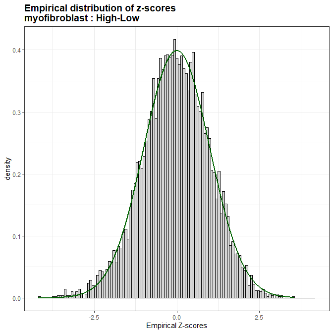

```
##
## $`myofibroblast.Low-High`
```

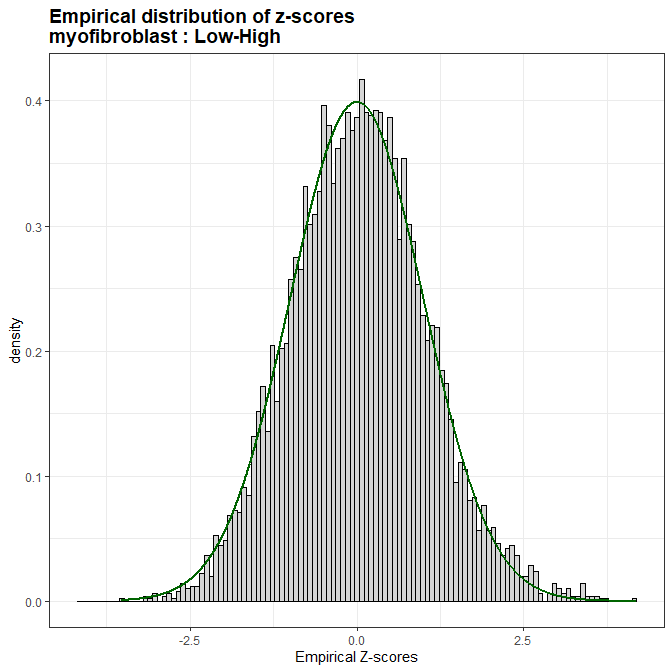

```r
DE_info_emp$z_distr_plots_emp_pval
## $`CAF.High-Low`
```

(Note: if plotting does not work, it might be necessary to run these plot commands in the console)

In general, these plots looks fine, except for the Malignant cells. As discussed in the previous plots: there might be an issue here. One possible explanation might be that there is additional substructure in the data. This could make sense because the pEMT high group consists both of pEMT very-high and pEMT high samples according to the finer subdivision/metadata column `pEMT_fine`. Another reason for the possible substructure: malignant cells of each tumor are very different because of genetic aberrations.

If we compare the empirical p-values to the original ones before for the malignant cells, we see that through the empirical null procedure, we lost some DE genes in malignant cells. But it is likely that the DE genes that er kept are the most bona fide ones.

As additional check, we will look for the concordance between p-values rankings of the original and empirical DE analysis (via ranking-line and upset plots):

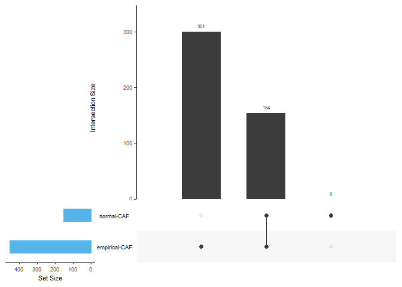

```
##
## [[1]][[2]]
```

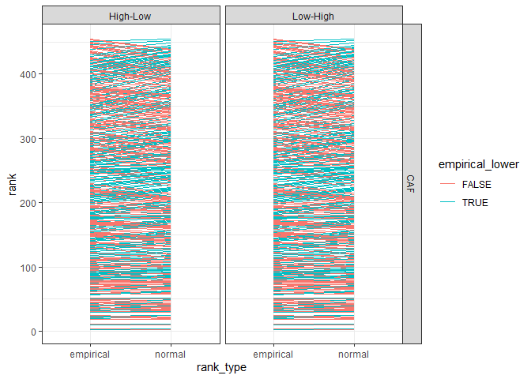

```
##
##
## [[2]]
## [[2]][[1]]
```

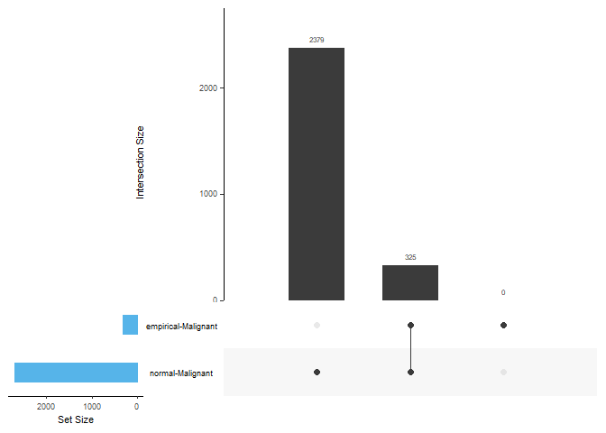

```
##
## [[2]][[2]]
```

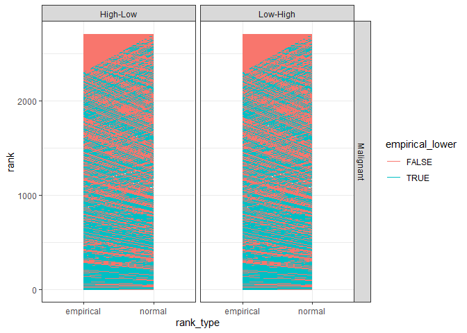

```
##
##
## [[3]]
## [[3]][[1]]
```

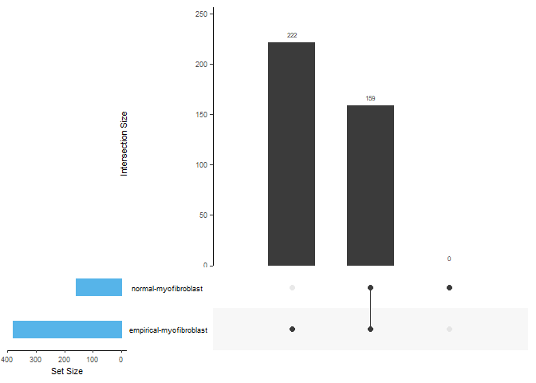

```
##
## [[3]][[2]]
```

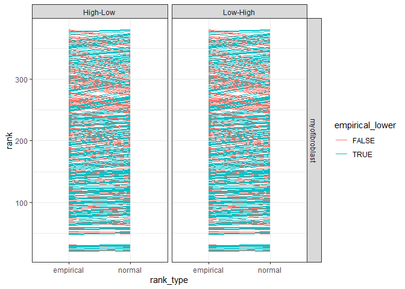

```r
comparison_plots = DE_info$celltype_de$de_output_tidy$cluster_id %>% unique() %>% lapply(function(celltype_oi, adjusted = FALSE){
  if(adjusted == TRUE){
      de_genes_normal = DE_info$celltype_de$de_output_tidy %>% filter(cluster_id == celltype_oi) %>% filter(p_adj.glb <= 0.05) %>% pull(gene) %>% unique()
      de_genes_emp = DE_info_emp$de_output_tidy_emp %>% filter(cluster_id == celltype_oi) %>% filter(p_adj_emp <= 0.05) %>% pull(gene) %>% unique()

  } else {
      de_genes_normal = DE_info$celltype_de$de_output_tidy %>% filter(cluster_id == celltype_oi) %>% filter(p_val <= 0.05) %>% pull(gene) %>% unique()
      de_genes_emp = DE_info_emp$de_output_tidy_emp %>% filter(cluster_id == celltype_oi) %>% filter(p_emp <= 0.05) %>% pull(gene) %>% unique()

  }

  upset_df = tibble(gene = union(de_genes_normal, de_genes_emp), normal = as.double(gene %in% de_genes_normal), empirical = as.double(gene %in% de_genes_emp)) %>% data.frame() %>% magrittr::set_rownames(.$gene) %>% dplyr::select(-gene)
  colnames(upset_df) = paste(colnames(upset_df), celltype_oi, sep = "-")
  p_upset = UpSetR::upset(upset_df, sets.bar.color = "#56B4E9", order.by = "freq", empty.intersections = "on")

  p_ranking = DE_info_emp$de_output_tidy_emp %>% filter(gene %in% union(de_genes_normal, de_genes_emp) & cluster_id == celltype_oi) %>% group_by(cluster_id, contrast) %>% mutate(normal = rank(p_val), empirical = rank(p_emp)) %>% filter(normal != empirical) %>% mutate(empirical_lower = empirical < normal) %>% tidyr::gather(rank_type, rank, normal:empirical) %>% dplyr::select(gene, rank_type, rank, empirical_lower)  %>%
    ggplot(aes(rank_type, rank, group = gene, color = empirical_lower)) + geom_line(aes(group = gene)) + facet_grid(cluster_id ~ contrast) + theme_bw()

  return(list(p_upset, p_ranking))

}, adjusted = FALSE)
comparison_plots
## [[1]]
## [[1]][[1]]
```

### Conclusion of the diagnostic plots concerning the DE analysis

P-value histograms of both the normal and empirical p-values indicate there might be some problems in the DE model definition, certainly for malignant cells. If possible it might be a good idea to include more covariates in the model, or use the `pEMT_fine` group definition instead.

Because of these issues (that point to violations to the assumptions that should be fulfilled for having accurate theoretical p-values), we decide to continue based on the empirical p-values in this case study.

**User adaptation recommended**

```r
empirical_pval = TRUE
if(empirical_pval == FALSE){
  celltype_de = DE_info$celltype_de$de_output_tidy
} else {
  celltype_de = DE_info_emp$de_output_tidy_emp %>% dplyr::select(-p_val, -p_adj) %>% dplyr::rename(p_val = p_emp, p_adj = p_adj_emp)
}
```

### Combine DE information for ligand-senders and receptors-receivers (similar to step1 - `abundance_expression_info$sender_receiver_info`)

```r
sender_receiver_de = combine_sender_receiver_de(
  sender_de = celltype_de,
  receiver_de = celltype_de,
  senders_oi = senders_oi,
  receivers_oi = receivers_oi,
  lr_network = lr_network
)
```

```r
sender_receiver_de %>% head(20)
## # A tibble: 20 x 12
##    contrast sender        receiver      ligand receptor lfc_ligand lfc_receptor ligand_receptor_lfc_avg p_val_ligand p_adj_ligand p_val_receptor p_adj_receptor
##    <chr>    <chr>         <chr>         <chr>  <chr>         <dbl>        <dbl>                   <dbl>        <dbl>        <dbl>          <dbl>          <dbl>
##  1 High-Low Malignant     Malignant     IL20   IL20RB         8.59       2.33                      5.46     0.0107          0.999        0.0215           0.999
##  2 High-Low Malignant     CAF           IL1B   ADRB2          3.58       6.75                      5.16     0.0862          0.999        0.00522          0.991
##  3 High-Low Malignant     Malignant     IL20   IL22RA1        8.59       1.05                      4.82     0.0107          0.999        0.191            0.999
##  4 Low-High Malignant     Malignant     IGSF11 CLEC2L         4.01       4.88                      4.44     0.0430          0.999        0.0783           0.999
##  5 Low-High Malignant     Malignant     CLEC2L IGSF11         4.88       4.01                      4.44     0.0783          0.999        0.0430           0.999
##  6 High-Low Malignant     Malignant     IL24   IL20RB         6.28       2.33                      4.30     0.0164          0.999        0.0215           0.999
##  7 High-Low CAF           Malignant     SAA1   FPR1           6.74       1.76                      4.25     0.0198          0.991        0.482            0.999
##  8 High-Low CAF           Malignant     SAA1   TLR2           6.74       1.73                      4.24     0.0198          0.991        0.157            0.999
##  9 High-Low Malignant     Malignant     IL1B   IL12RB2        3.58       4.86                      4.22     0.0862          0.999        0.0472           0.999
## 10 High-Low Malignant     myofibroblast LIPC   LRP1           8.11       0.0842                    4.10     0.0877          0.999        0.868            0.995
## 11 High-Low Malignant     Malignant     IL20   IL20RA         8.59      -0.477                     4.06     0.0107          0.999        0.784            0.999
## 12 High-Low Malignant     CAF           PTHLH  ADRB2          1.32       6.75                      4.04     0.306           0.999        0.00522          0.991
## 13 High-Low Malignant     Malignant     TIMP3  MMP9           3.37       4.69                      4.03     0.0393          0.999        0.0561           0.999
## 14 Low-High Malignant     Malignant     MPDZ   CLDN5          1.91       6.04                      3.98     0.277           0.999        0.00967          0.999
## 15 High-Low Malignant     CAF           LIPC   LRP1           8.11      -0.258                     3.93     0.0877          0.999        0.555            0.991
## 16 High-Low Malignant     Malignant     LIPC   LRP1           8.11      -0.28                      3.91     0.0877          0.999        0.735            0.999
## 17 High-Low myofibroblast Malignant     TGFB2  TGFBR2         4.89       2.89                      3.89     0.000689        0.328        0.0505           0.999
## 18 Low-High Malignant     Malignant     FGF12  SCN9A          2.7        5.07                      3.88     0.147           0.999        0.0427           0.999
## 19 Low-High Malignant     Malignant     FGF13  SCN9A          2.66       5.07                      3.86     0.202           0.999        0.0427           0.999
## 20 High-Low Malignant     Malignant     TGFB2  TGFBR2         4.76       2.89                      3.82     0.0234          0.999        0.0505           0.999
```

# Step 3: Predict NicheNet ligand activities and NicheNet ligand-target links based on these differential expression results

## Define the parameters for the NicheNet ligand activity analysis

Here, we need to define the thresholds that will be used to consider genes as differentially expressed or not (logFC, p-value, decision whether to use adjusted or normal p-value, minimum fraction of cells that should express a gene in at least one sample in a group, whether to use the normal p-values or empirical p-values).

NicheNet ligand activity will then be calculated as the enrichment of predicted target genes of ligands in this set of DE genes compared to the genomic background. Here we choose for a minimum logFC of 0.50, maximum p-value of 0.05, and minimum fraction of expression of 0.05.

**User adaptation recommended**

```r
logFC_threshold = 0.50
p_val_threshold = 0.05
fraction_cutoff = 0.05
```

We will here choose for applying the p-value cutoff on the normal p-values, and not on the p-values corrected for multiple testing. This choice was made here because of lack of statistical power due to pseudobulking and the fact that this dataset has only a few samples per group.

**User adaptation recommended**

```r
p_val_adj = FALSE
```

For the NicheNet ligand-target inference, we also need to select which top n of the predicted target genes will be considered (here: top 250 targets per ligand).

**User adaptation recommended**

```r
top_n_target = 250
```

The NicheNet ligand activity analysis can be run in parallel for each receiver cell type, by changing the number of cores as defined here. This is only recommended if you have many receiver cell type.

**User adaptation recommended**

```r
verbose = TRUE
n.cores = 1
```

## Run the NicheNet ligand activity analysis

```r
start_time <- Sys.time()
ligand_activities_targets_DEgenes = suppressMessages(suppressWarnings(get_ligand_activities_targets_DEgenes(
  receiver_de = celltype_de,
  receivers_oi = receivers_oi,
  ligand_target_matrix = ligand_target_matrix,
  logFC_threshold = logFC_threshold,
  p_val_threshold = p_val_threshold,
  p_val_adj = p_val_adj,
  top_n_target = top_n_target,
  verbose = verbose,
  n.cores = n.cores
)))
## [1] "receiver_oi:"
## [1] "CAF"
## [1] "contrast_oi:"
## [1] "High-Low"
## [1] "Number of upregulated DE genes (gene set of interest): "
## [1] 252
## [1] "Number of downregulated DE genes (gene set of interest): "
## [1] 194
## [1] "contrast_oi:"
## [1] "Low-High"
## [1] "Number of upregulated DE genes (gene set of interest): "
## [1] 194
## [1] "Number of downregulated DE genes (gene set of interest): "
## [1] 252
## [1] "receiver_oi:"
## [1] "Malignant"
## [1] "contrast_oi:"
## [1] "High-Low"
## [1] "Number of upregulated DE genes (gene set of interest): "
## [1] 233
## [1] "Number of downregulated DE genes (gene set of interest): "
## [1] 74
## [1] "contrast_oi:"
## [1] "Low-High"
## [1] "Number of upregulated DE genes (gene set of interest): "
## [1] 74
## [1] "Number of downregulated DE genes (gene set of interest): "
## [1] 233
## [1] "receiver_oi:"
## [1] "myofibroblast"
## [1] "contrast_oi:"
## [1] "High-Low"
## [1] "Number of upregulated DE genes (gene set of interest): "
## [1] 236
## [1] "Number of downregulated DE genes (gene set of interest): "
## [1] 141
## [1] "contrast_oi:"
## [1] "Low-High"
## [1] "Number of upregulated DE genes (gene set of interest): "
## [1] 141
## [1] "Number of downregulated DE genes (gene set of interest): "
## [1] 236
end_time <- Sys.time()
end_time - start_time
## Time difference of 10.41583 mins
```

Check the DE genes used for the activity analysis

```r
ligand_activities_targets_DEgenes$de_genes_df %>% head(20)
## # A tibble: 20 x 6
##    gene      receiver logFC   p_val p_adj contrast
##    <chr>     <chr>    <dbl>   <dbl> <dbl> <chr>
##  1 SUMO1     CAF      0.903 0.0324  0.991 High-Low
##  2 CHST15    CAF      2.12  0.0265  0.991 High-Low
##  3 CD82      CAF      1.68  0.00253 0.991 High-Low
##  4 SNAPC1    CAF      1.42  0.00875 0.991 High-Low
##  5 COX7A2    CAF      0.903 0.0161  0.991 High-Low
##  6 LDLR      CAF      0.992 0.0353  0.991 High-Low
##  7 ALAS1     CAF      1.48  0.0192  0.991 High-Low
##  8 ST7L      CAF      2.24  0.00155 0.991 High-Low
##  9 ACSL1     CAF      1.32  0.0296  0.991 High-Low
## 10 HDAC1     CAF      1.2   0.0170  0.991 High-Low
## 11 SNRPB2    CAF      0.731 0.0340  0.991 High-Low
## 12 MRPL33    CAF      0.943 0.0109  0.991 High-Low
## 13 PELO      CAF      1.07  0.0272  0.991 High-Low
## 14 MED10     CAF      0.971 0.0199  0.991 High-Low
## 15 ATP2C1    CAF      1.63  0.0343  0.991 High-Low
## 16 SLC12A2   CAF      1.52  0.00567 0.991 High-Low
## 17 STC1      CAF      7.5   0.0140  0.991 High-Low
## 18 H2BC3     CAF      5.32  0.0403  0.991 High-Low
## 19 LINC00473 CAF      2.57  0.0220  0.991 High-Low
## 20 PELI1     CAF      1.44  0.0402  0.991 High-Low
```

Check the output of the activity analysis

```r
ligand_activities_targets_DEgenes$ligand_activities %>% head(20)
## # A tibble: 20 x 8
## # Groups:   receiver, contrast [1]
##    ligand  activity contrast target   ligand_target_weight receiver direction_regulation activity_scaled
##    <chr>      <dbl> <chr>    <chr>                   <dbl> <chr>    <fct>                          <dbl>
##  1 A2M     0.00324  High-Low ADM                   0.00399 CAF      up                            0.0792
##  2 A2M     0.00324  High-Low BCL3                  0.00486 CAF      up                            0.0792
##  3 A2M     0.00324  High-Low LDLR                  0.00415 CAF      up                            0.0792
##  4 A2M     0.00324  High-Low MIDEAS                0.00418 CAF      up                            0.0792
##  5 A2M     0.00324  High-Low PLAUR                 0.00425 CAF      up                            0.0792
##  6 A2M     0.00324  High-Low PRDM1                 0.00437 CAF      up                            0.0792
##  7 A2M     0.00324  High-Low TRIB1                 0.00442 CAF      up                            0.0792
##  8 AANAT  -0.000133 High-Low BCL3                  0.00387 CAF      up                           -1.47
##  9 AANAT  -0.000133 High-Low EIF5A                 0.00302 CAF      up                           -1.47
## 10 AANAT  -0.000133 High-Low HDAC1                 0.00360 CAF      up                           -1.47
## 11 AANAT  -0.000133 High-Low LDLR                  0.00301 CAF      up                           -1.47
## 12 AANAT  -0.000133 High-Low MIDEAS                0.00324 CAF      up                           -1.47
## 13 AANAT  -0.000133 High-Low NR4A2                 0.00297 CAF      up                           -1.47
## 14 AANAT  -0.000133 High-Low SLC2A1                0.00307 CAF      up                           -1.47
## 15 AANAT  -0.000133 High-Low TRIB1                 0.00306 CAF      up                           -1.47
## 16 AANAT  -0.000133 High-Low USP3                  0.00332 CAF      up                           -1.47
## 17 ABCA1   0.00573  High-Low AURKAIP1              0.0393  CAF      up                            1.22
## 18 ABCA1   0.00573  High-Low CXCL2                 0.0403  CAF      up                            1.22
## 19 ABCA1   0.00573  High-Low CXCL6                 0.0442  CAF      up                            1.22
## 20 ABCA1   0.00573  High-Low ELOVL4                0.0442  CAF      up                            1.22
```

# Step 4: Use the information collected above to prioritize all sender-ligand—receiver-receptor pairs.

In the 3 previous steps, we calculated expression, differential expression and NicheNet activity information. Now we will combine these different types of information in one prioritization scheme.

MultiNicheNet allows the user to define the weights of the following criteria to prioritize ligand-receptor interactions:

- Upregulation of the ligand in a sender cell type and/or upregulation of the receptor in a receiver cell type - in the condition of interest. : `scaled_lfc_ligand`, `scaled_p_val_ligand`, `scaled_lfc_receptor`, and `scaled_p_val_receptor`
- Sufficiently high expression levels of ligand and receptor in many samples of the same group (to mitigate the influence of outlier samples). : `fraction_expressing_ligand_receptor`
- Cell-type and condition specific expression of the ligand in the sender cell type and receptor in the receiver cell type (to mitigate the influence of upregulated but still relatively weakly expressed ligands/receptors) : `scaled_avg_exprs_ligand`, `scaled_avg_frq_ligand`, `scaled_avg_exprs_receptor`, and `scaled_avg_frq_receptor`
- High NicheNet ligand activity, to further prioritize ligand-receptor pairs based on their predicted effect of the ligand-receptor interaction on the gene expression in the receiver cell type : `scaled_activity` and `scaled_activity_scaled` (scaled_activity=absolute value of ligand activity; scaled_activity_scaled=scaled ligand activity value that is comparable between different receiver settings - recommended to put more weight on this)
- High relative abundance of sender and/or receiver in the condition of interest: `scaled_abundance_sender` and `scaled_abundance_receiver`

The different properties of the sender-ligand—receiver-receptor pairs can be weighted according to the user’s preference and insight in the dataset at hand.

## Define the prioritization weights, and prepare grouping objects

We will set our preference for this dataset as follows:

**User adaptation recommended**

```r
prioritizing_weights_DE = c("de_ligand" = 5,
                         "de_receptor" = 6)
prioritizing_weights_activity = c("activity_scaled" = 3)

prioritizing_weights_expression_specificity = c("exprs_ligand" = 4,
                         "exprs_receptor" = 2)

prioritizing_weights_expression_sufficiency = c("frac_exprs_ligand_receptor" = 2)

prioritizing_weights_relative_abundance = c( "abund_sender" = 0,
                         "abund_receiver" = 0)
```

```r
prioritizing_weights = c(prioritizing_weights_DE,
                         prioritizing_weights_activity,
                         prioritizing_weights_expression_specificity,
                         prioritizing_weights_expression_sufficiency,
                         prioritizing_weights_relative_abundance)
```

Make necessary grouping data frame

```r
sender_receiver_tbl = sender_receiver_de %>% dplyr::distinct(sender, receiver)

metadata_combined = SummarizedExperiment::colData(sce) %>% tibble::as_tibble()

if(!is.na(covariates)){
  grouping_tbl = metadata_combined[,c(sample_id, group_id, covariates)] %>% tibble::as_tibble() %>% dplyr::distinct()
  colnames(grouping_tbl) = c("sample","group",covariates)
} else {
  grouping_tbl = metadata_combined[,c(sample_id, group_id)] %>% tibble::as_tibble() %>% dplyr::distinct()
  colnames(grouping_tbl) = c("sample","group")
}
```

Crucial note: grouping_tbl: group should be the same as in the contrast_tbl, and the expression ino tables! Rename accordingly if this would not be the case. If you followed the guidelines of this tutorial closely, there should be no problem.

## Run the prioritization

```r
prioritization_tables = suppressMessages(generate_prioritization_tables(
  sender_receiver_info = abundance_expression_info$sender_receiver_info,
  sender_receiver_de = sender_receiver_de,
  ligand_activities_targets_DEgenes = ligand_activities_targets_DEgenes,
  contrast_tbl = contrast_tbl,
  sender_receiver_tbl = sender_receiver_tbl,
  grouping_tbl = grouping_tbl,
  prioritizing_weights = prioritizing_weights,
  fraction_cutoff = fraction_cutoff,
  abundance_data_receiver = abundance_expression_info$abundance_data_receiver,
  abundance_data_sender = abundance_expression_info$abundance_data_sender
))
```

Check the output tables

First: group-based summary table

```r
prioritization_tables$group_prioritization_tbl %>% head(20)
## # A tibble: 20 x 54
##    contrast group sender        receiver  ligand receptor lfc_ligand lfc_receptor ligand_receptor_~ p_val_ligand p_adj_ligand p_val_receptor p_adj_receptor activity direction_regul~ activity_scaled lr_interaction id    avg_ligand_group avg_receptor_gr~
##    <chr>    <chr> <chr>         <chr>     <chr>  <chr>         <dbl>        <dbl>             <dbl>        <dbl>        <dbl>          <dbl>          <dbl>    <dbl> <fct>                      <dbl> <chr>          <chr>            <dbl>            <dbl>
##  1 High-Low High  Malignant     CAF       IL1B   ADRB2        3.58          6.75              5.16        0.0862        0.999        0.00522          0.991  1.34e-2 up                        4.75   IL1B_ADRB2     IL1B~            0.217            0.214
##  2 High-Low High  Malignant     CAF       IL1B   ADRB2        3.58          6.75              5.16        0.0862        0.999        0.00522          0.991  1.43e-4 down                      0.466  IL1B_ADRB2     IL1B~            0.217            0.214
##  3 Low-High Low   myofibroblast Malignant MPDZ   CLDN5        0.318         6.04              3.18        0.581         0.990        0.00967          0.999 -1.01e-3 up                       -0.155  MPDZ_CLDN5     MPDZ~            0.753            1.18
##  4 Low-High Low   myofibroblast Malignant MPDZ   CLDN5        0.318         6.04              3.18        0.581         0.990        0.00967          0.999  1.52e-2 down                      1.56   MPDZ_CLDN5     MPDZ~            0.753            1.18
##  5 High-Low High  Malignant     Malignant IL20   IL20RB       8.59          2.33              5.46        0.0107        0.999        0.0215           0.999  1.34e-2 up                        1.11   IL20_IL20RB    IL20~            0.272            3.19
##  6 High-Low High  Malignant     Malignant IL20   IL20RB       8.59          2.33              5.46        0.0107        0.999        0.0215           0.999 -1.08e-3 down                     -0.198  IL20_IL20RB    IL20~            0.272            3.19
##  7 High-Low High  myofibroblast Malignant CCN1   TLR2         0.185         1.73              0.958       0.491         0.990        0.157            0.999  9.29e-3 up                        0.0388 CCN1_TLR2      CCN1~            4.82             0.708
##  8 High-Low High  myofibroblast Malignant CCN1   TLR2         0.185         1.73              0.958       0.491         0.990        0.157            0.999  1.24e-2 down                      8.03   CCN1_TLR2      CCN1~            4.82             0.708
##  9 High-Low High  myofibroblast Malignant CCN1   ITGA5        0.185         2.44              1.31        0.491         0.990        0.0303           0.999  9.29e-3 up                        0.0388 CCN1_ITGA5     CCN1~            4.82             1.82
## 10 High-Low High  myofibroblast Malignant CCN1   ITGA5        0.185         2.44              1.31        0.491         0.990        0.0303           0.999  1.24e-2 down                      8.03   CCN1_ITGA5     CCN1~            4.82             1.82
## 11 High-Low High  CAF           Malignant DCN    TLR2         0.0461        1.73              0.888       0.885         0.998        0.157            0.999  8.47e-3 up                       -0.171  DCN_TLR2       DCN_~            8.09             0.708
## 12 High-Low High  CAF           Malignant DCN    TLR2         0.0461        1.73              0.888       0.885         0.998        0.157            0.999  1.22e-2 down                      7.90   DCN_TLR2       DCN_~            8.09             0.708
## 13 High-Low High  myofibroblast Malignant CCN1   ITGA6        0.185         0.754             0.470       0.491         0.990        0.0764           0.999  9.29e-3 up                        0.0388 CCN1_ITGA6     CCN1~            4.82             2.95
## 14 High-Low High  myofibroblast Malignant CCN1   ITGA6        0.185         0.754             0.470       0.491         0.990        0.0764           0.999  1.24e-2 down                      8.03   CCN1_ITGA6     CCN1~            4.82             2.95
## 15 High-Low High  Malignant     Malignant AREG   MMP9         2.3           4.69              3.50        0.0228        0.999        0.0561           0.999  9.04e-3 up                       -0.0256 AREG_MMP9      AREG~            1.85             0.263
## 16 High-Low High  Malignant     Malignant AREG   MMP9         2.3           4.69              3.50        0.0228        0.999        0.0561           0.999  6.17e-3 down                      4.23   AREG_MMP9      AREG~            1.85             0.263
## 17 High-Low High  CAF           Malignant DCN    EGFR         0.0461        0.908             0.477       0.885         0.998        0.101            0.999  8.47e-3 up                       -0.171  DCN_EGFR       DCN_~            8.09             1.52
## 18 High-Low High  CAF           Malignant DCN    EGFR         0.0461        0.908             0.477       0.885         0.998        0.101            0.999  1.22e-2 down                      7.90   DCN_EGFR       DCN_~            8.09             1.52
## 19 High-Low High  myofibroblast Malignant CCN1   SDC4         0.185         0.456             0.320       0.491         0.990        0.293            0.999  9.29e-3 up                        0.0388 CCN1_SDC4      CCN1~            4.82             3.56
## 20 High-Low High  myofibroblast Malignant CCN1   SDC4         0.185         0.456             0.320       0.491         0.990        0.293            0.999  1.24e-2 down                      8.03   CCN1_SDC4      CCN1~            4.82             3.56
## # ... with 34 more variables: ligand_receptor_prod_group <dbl>, fraction_ligand_group <dbl>, fraction_receptor_group <dbl>, ligand_receptor_fraction_prod_group <dbl>, rel_abundance_scaled_sender <dbl>, rel_abundance_scaled_receiver <dbl>,
## #   sender_receiver_rel_abundance_avg <dbl>, lfc_pval_ligand <dbl>, scaled_lfc_ligand <dbl>, scaled_p_val_ligand <dbl>, scaled_lfc_pval_ligand <dbl>, lfc_pval_receptor <dbl>, scaled_lfc_receptor <dbl>, scaled_p_val_receptor <dbl>,
## #   scaled_lfc_pval_receptor <dbl>, activity_up <dbl>, activity_scaled_up <dbl>, scaled_activity_scaled_up <dbl>, scaled_activity_up <dbl>, activity_down <dbl>, activity_scaled_down <dbl>, scaled_activity_scaled_down <dbl>, scaled_activity_down <dbl>,
## #   scaled_avg_exprs_ligand <dbl>, scaled_avg_frq_ligand <dbl>, pb_ligand_group <dbl>, scaled_pb_ligand <dbl>, scaled_avg_exprs_receptor <dbl>, scaled_avg_frq_receptor <dbl>, pb_receptor_group <dbl>, scaled_pb_receptor <dbl>,
## #   fraction_expressing_ligand_receptor <dbl>, prioritization_score <dbl>, top_group <chr>
```

Second: sample-based summary table: contains expression information of each LR pair per sample

```r
prioritization_tables$sample_prioritization_tbl %>% head(20)
## # A tibble: 20 x 26
##    sample sender        receiver ligand receptor avg_ligand avg_receptor ligand_receptor~ fraction_ligand fraction_recept~ ligand_receptor~ pb_ligand pb_receptor ligand_receptor~ group prioritization_~ lr_interaction id    scaled_LR_prod scaled_LR_frac
##    <chr>  <chr>         <chr>    <chr>  <chr>         <dbl>        <dbl>            <dbl>           <dbl>            <dbl>            <dbl>     <dbl>       <dbl>            <dbl> <chr>            <dbl> <chr>          <chr>          <dbl>          <dbl>
##  1 HN17   Myeloid       Myeloid  HLA.D~ CD74           8.76        12.5             110.            1                    1            1         10.1        10.6             107.  High                NA HLA.DMA_CD74   HLA.~          1.22           0.817
##  2 HN17   Malignant     Myeloid  MIF    CD74           8.40        12.5             105.            1                    1            1          9.47       10.6             100.  High                NA MIF_CD74       MIF_~          1.53           1.09
##  3 HN16   Malignant     Myeloid  MIF    CD74           8.61        11.9             102.            0.988                1            0.988      9.38       10.7             101.  High                NA MIF_CD74       MIF_~          1.28           0.345
##  4 HN18   Myeloid       Myeloid  HLA.D~ CD74           7.78        12.6              98.3           1                    1            1         10.1        10.8             109.  High                NA HLA.DMA_CD74   HLA.~          0.954          0.817
##  5 HN5    Myeloid       Myeloid  HLA.D~ CD74           7.76        12.2              94.5           1                    1            1         10.2        10.8             111.  High                NA HLA.DMA_CD74   HLA.~          0.864          0.817
##  6 HN26   Myeloid       Myeloid  CCL19  CCR7           8.16        11.5              94.2           1                    1            1          9.33        9.83             91.6 Low                 NA CCL19_CCR7     CCL1~          2.60           2.41
##  7 HN5    Malignant     Myeloid  MIF    CD74           7.72        12.2              93.9           0.971                1            0.971      9.09       10.8              98.5 High                NA MIF_CD74       MIF_~          0.618         -0.661
##  8 HN5    Myeloid       CAF      HLA.D~ CD63          11.2          8.15             90.9           1                    1            1         10.7         9.44            101.  High                NA HLA.DRA_CD63   HLA.~          1.06           0.485
##  9 HN18   Malignant     Myeloid  MIF    CD74           7.20        12.6              90.9           0.958                1            0.958      9.40       10.8             102.  High                NA MIF_CD74       MIF_~          0.374         -1.48
## 10 HN5    Myeloid       Myeloid  HLA.D~ CD74           7.38        12.2              89.8           1                    1            1         10.1        10.8             110.  High                NA HLA.DMB_CD74   HLA.~          1.40           1.26
## 11 HN18   CAF           Myeloid  MIF    CD74           7.00        12.6              88.4           0.944                1            0.944      9.64       10.8             104.  High                NA MIF_CD74       MIF_~          1.22           0.992
## 12 HN5    myofibroblast Myeloid  MIF    CD74           7.21        12.2              87.8           1                    1            1          9.50       10.8             103.  High                NA MIF_CD74       MIF_~          1.52           1.26
## 13 HN18   myofibroblast Myeloid  MIF    CD74           6.82        12.6              86.2           1                    1            1          9.65       10.8             104.  High                NA MIF_CD74       MIF_~          1.42           1.26
## 14 HN17   CAF           Myeloid  MIF    CD74           6.85        12.5              85.7           0.892                1            0.892      9.94       10.6             105.  High                NA MIF_CD74       MIF_~          1.08           0.356
## 15 HN22   Endothelial   Endothe~ MIF    CD74           8.39        10.2              85.2           1                    1            1          9.22        9.49             87.5 High                NA MIF_CD74       MIF_~          2.35           0.990
## 16 HN22   Malignant     Myeloid  CXCL14 CXCR4          8.69         9.81             85.2           0.976                1            0.976      9.37        9.51             89.2 High                NA CXCL14_CXCR4   CXCL~          1.95           1.15
## 17 HN5    CAF           Myeloid  MIF    CD74           6.96        12.2              84.7           0.973                1            0.973      9.21       10.8              99.8 High                NA MIF_CD74       MIF_~          1.02           1.34
## 18 HN6    Malignant     Myeloid  MIF    CD74           7.77        10.9              84.5           0.968                1            0.968      9.03       10.2              92.4 Low                 NA MIF_CD74       MIF_~         -0.138         -0.862
## 19 HN22   Malignant     Endothe~ MIF    CD74           8.23        10.2              83.7           1                    1            1          9.29        9.49             88.2 High                NA MIF_CD74       MIF_~          2.13           0.870
## 20 HN28   Myeloid       Myeloid  HLA.D~ CD63          11.0          7.57             83.5           1                    1            1          9.60        9.06             86.9 High                NA HLA.DRA_CD63   HLA.~          1.06           0.607
## # ... with 6 more variables: scaled_LR_pb_prod <dbl>, n_cells_receiver <dbl>, keep_receiver <dbl>, n_cells_sender <dbl>, keep_sender <dbl>, keep_sender_receiver <fct>
```

# Step 5: Optional: unsupervised analysis of sender-ligand—receiver-receptor pair expression values per sample, to see heterogeneity in cell-cell communication.

**User adaptation recommended**

```r
return_lr_prod_matrix = TRUE
if(return_lr_prod_matrix == TRUE){

    ids_oi = prioritization_tables$group_prioritization_tbl %>% dplyr::filter(fraction_expressing_ligand_receptor > 0)  %>% dplyr::pull(id) %>% unique()

    lr_prod_df = abundance_expression_info$sender_receiver_info$pb_df %>% dplyr::inner_join(grouping_tbl, by = "sample") %>% dplyr::mutate(lr_interaction = paste(ligand, receptor, sep = "_")) %>% dplyr::mutate(id = paste(lr_interaction, sender, receiver, sep = "_")) %>% dplyr::select(sample, id, ligand_receptor_pb_prod) %>% dplyr::filter(id %in% ids_oi) %>% dplyr::distinct() %>% tidyr::spread(id, ligand_receptor_pb_prod)
    lr_prod_mat = lr_prod_df %>% dplyr::select(-sample) %>% data.frame() %>% as.matrix()
    rownames(lr_prod_mat) = lr_prod_df$sample

    col_remove = lr_prod_mat %>% apply(2,function(x)sum(x != 0)) %>% .[. == 0] %>% names()
    row_remove = lr_prod_mat %>% apply(1,function(x)sum(x != 0)) %>% .[. == 0] %>% names()

    lr_prod_mat = lr_prod_mat %>% .[rownames(.) %>% generics::setdiff(col_remove),colnames(.) %>% generics::setdiff(col_remove)]
  } else {
    lr_prod_mat = NULL
}
```

# Step 6: Add information on prior knowledge and expression correlation between LR and target expression.

```r
lr_target_prior_cor = lr_target_prior_cor_inference(prioritization_tables$group_prioritization_tbl$receiver %>% unique(), abundance_expression_info, celltype_de, grouping_tbl, prioritization_tables, ligand_target_matrix, logFC_threshold = logFC_threshold, p_val_threshold = p_val_threshold, p_val_adj = p_val_adj)
```

# Save all the output of MultiNicheNet

To avoid needing to redo the analysis later. All the output written down here is sufficient to make all in-built downstream visualizations.

**User adaptation recommended**

```r
path = "./"

multinichenet_output = list(
    celltype_info = abundance_expression_info$celltype_info,
    celltype_de = celltype_de,
    sender_receiver_info = abundance_expression_info$sender_receiver_info,
    sender_receiver_de =  sender_receiver_de,
    ligand_activities_targets_DEgenes = ligand_activities_targets_DEgenes,
    prioritization_tables = prioritization_tables,
    lr_prod_mat = lr_prod_mat,
    grouping_tbl = grouping_tbl,
    lr_target_prior_cor = lr_target_prior_cor
  )
multinichenet_output = make_lite_output(multinichenet_output)

save = FALSE
if(save == TRUE){
  saveRDS(multinichenet_output, paste0(path, "multinichenet_output.rds"))

}
```

# Visualization of the results of the cell-cell communication analysis

In a first instance, we will look at the broad overview of prioritized interactions via condition-specific Circos plots. We will filter on the prioritization score after removing interactions that are not upregulated in the condition of interest, and that are in no patient expressed in more than 5% of cells of a cell type (cf `fraction_cutoff`).

## Circos plot of top-prioritized links

(remark: there are still some bugs in the automatic circos plot function)

```r
prioritized_tbl_oi_high30 = get_top_n_lr_pairs(prioritization_tables, 30, groups_oi = "High")
prioritized_tbl_oi_low30 = get_top_n_lr_pairs(prioritization_tables, 30, groups_oi = "Low")
prioritized_tbl_oi_top30_all = get_top_n_lr_pairs(prioritization_tables, 30, rank_per_group = FALSE)
```

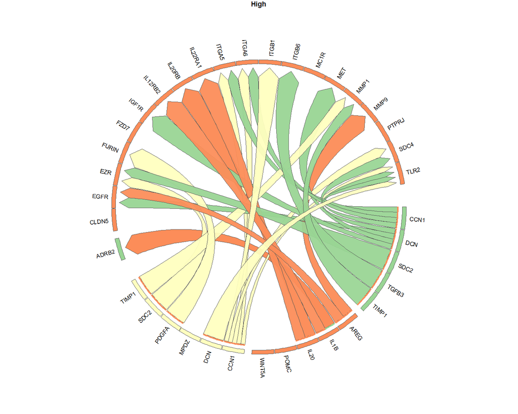

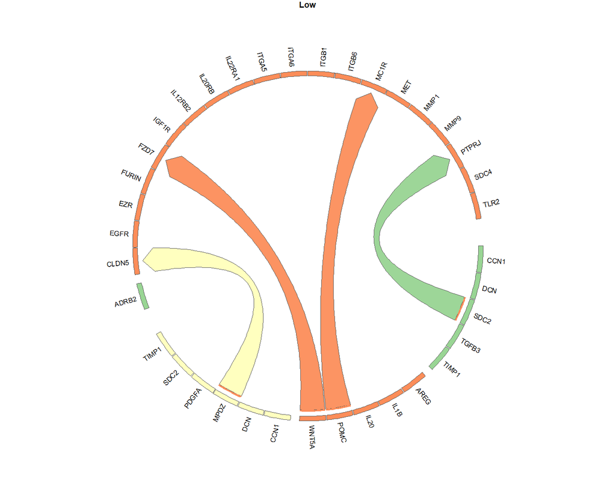

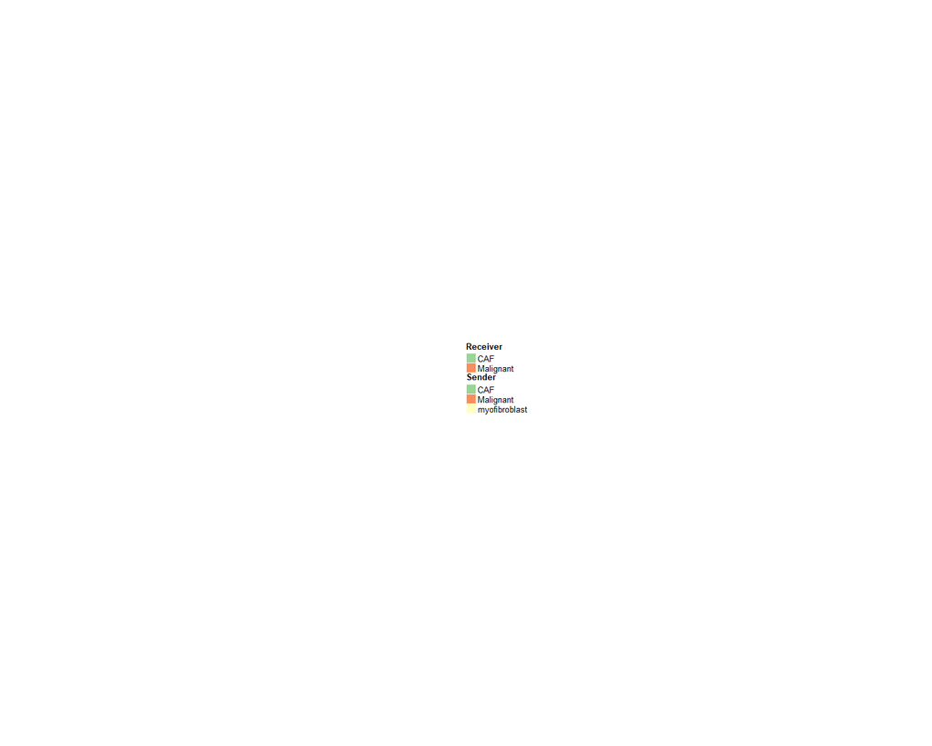

```r
# prioritized_tbl_oi_prep = multinichenet_output$prioritization_tables$group_prioritization_tbl %>%
#   filter(fraction_ligand_group > fraction_cutoff & fraction_receptor_group > fraction_cutoff) %>%
#   distinct(id, sender, receiver, ligand, receptor, group, prioritization_score, ligand_receptor_lfc_avg, fraction_expressing_ligand_receptor) %>%
#   filter(ligand_receptor_lfc_avg > 0 & fraction_expressing_ligand_receptor > 0) %>% top_n(30, prioritization_score)
#
# prioritized_tbl_oi_prep %>% dplyr::group_by(group) %>% dplyr::count()

prioritized_tbl_oi = multinichenet_output$prioritization_tables$group_prioritization_tbl %>%
  filter(id %in% prioritized_tbl_oi_top30_all$id) %>%
  distinct(id, sender, receiver, ligand, receptor, group) %>% left_join(prioritized_tbl_oi_top30_all)
prioritized_tbl_oi$prioritization_score[is.na(prioritized_tbl_oi$prioritization_score)] = 0

# prioritized_tbl_oi = lr_pairs_top30_all

senders_receivers = union(prioritized_tbl_oi$sender %>% unique(), prioritized_tbl_oi$receiver %>% unique())

colors_sender = RColorBrewer::brewer.pal(n = length(senders_receivers), name = 'Spectral') %>% magrittr::set_names(senders_receivers)
colors_receiver = RColorBrewer::brewer.pal(n = length(senders_receivers), name = 'Spectral') %>% magrittr::set_names(senders_receivers)

circos_list = make_circos_group_comparison(prioritized_tbl_oi, colors_sender, colors_receiver)
```

Now you can also make a full circos plot for one group of interest

```r
# group_oi = "High"
# prioritized_tbl_oi = multinichenet_output$prioritization_tables$group_prioritization_tbl %>%
#   filter(fraction_ligand_group > fraction_cutoff & fraction_receptor_group > fraction_cutoff & group == group_oi) %>%
#   distinct(id, sender, receiver, ligand, receptor, group, prioritization_score, ligand_receptor_lfc_avg, fraction_expressing_ligand_receptor) %>%
#   filter(ligand_receptor_lfc_avg > 0 & fraction_expressing_ligand_receptor > 0) %>% top_n(30, prioritization_score)
#
# senders_receivers = union(prioritized_tbl_oi$sender %>% unique(), prioritized_tbl_oi$receiver %>% unique())
#
# colors_sender = RColorBrewer::brewer.pal(n = length(senders_receivers), name = 'Spectral') %>% magrittr::set_names(senders_receivers)
# colors_receiver = RColorBrewer::brewer.pal(n = length(senders_receivers), name = 'Spectral') %>% magrittr::set_names(senders_receivers)
#
# circos_list = make_circos_one_group(prioritized_tbl_oi, colors_sender, colors_receiver)


circos_list = make_circos_one_group(prioritized_tbl_oi_high30, colors_sender, colors_receiver)
```

[figure not shown]

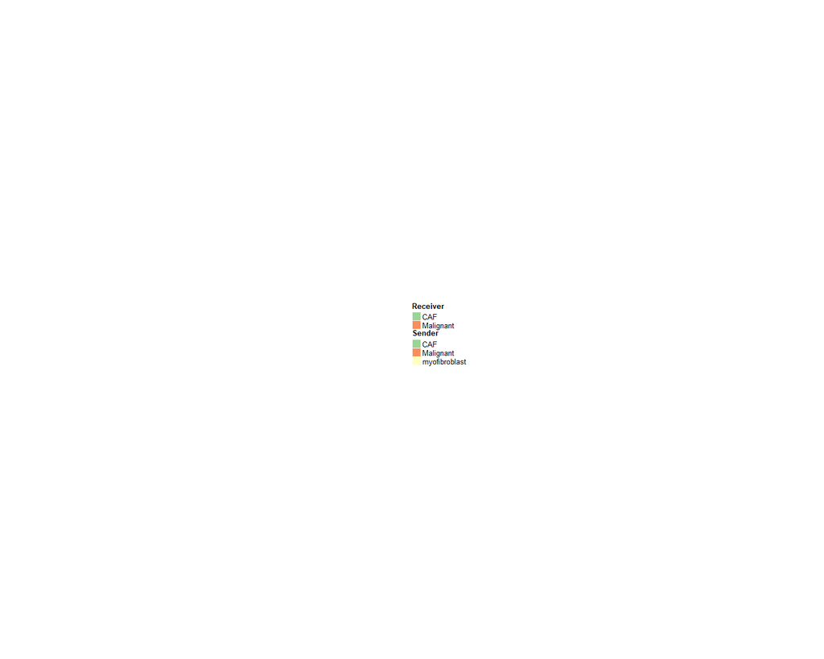

```r
circos_list = make_circos_one_group(prioritized_tbl_oi_low30, colors_sender, colors_receiver)
```

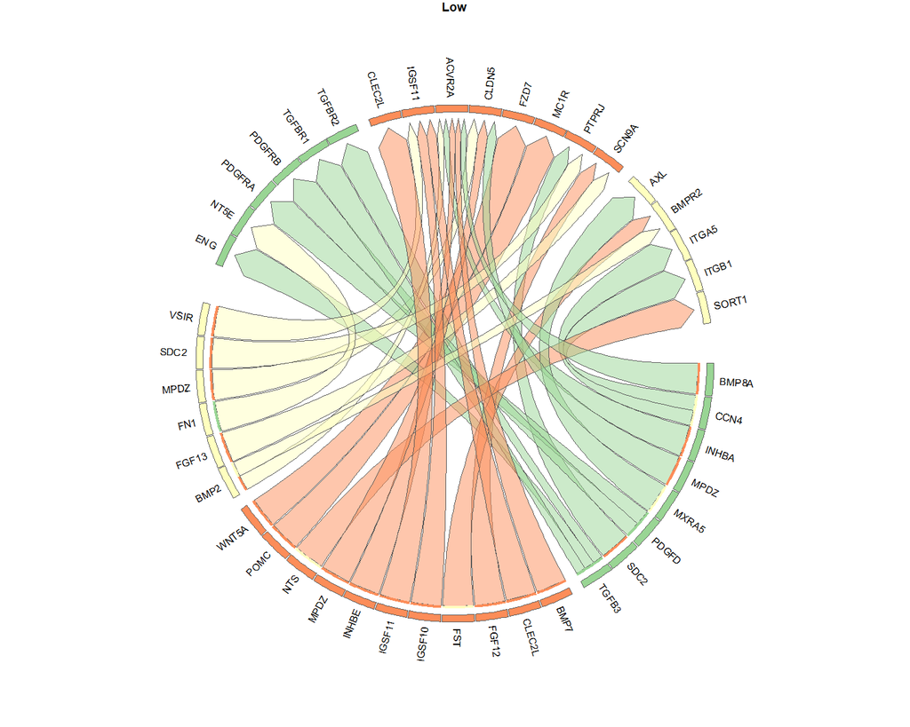

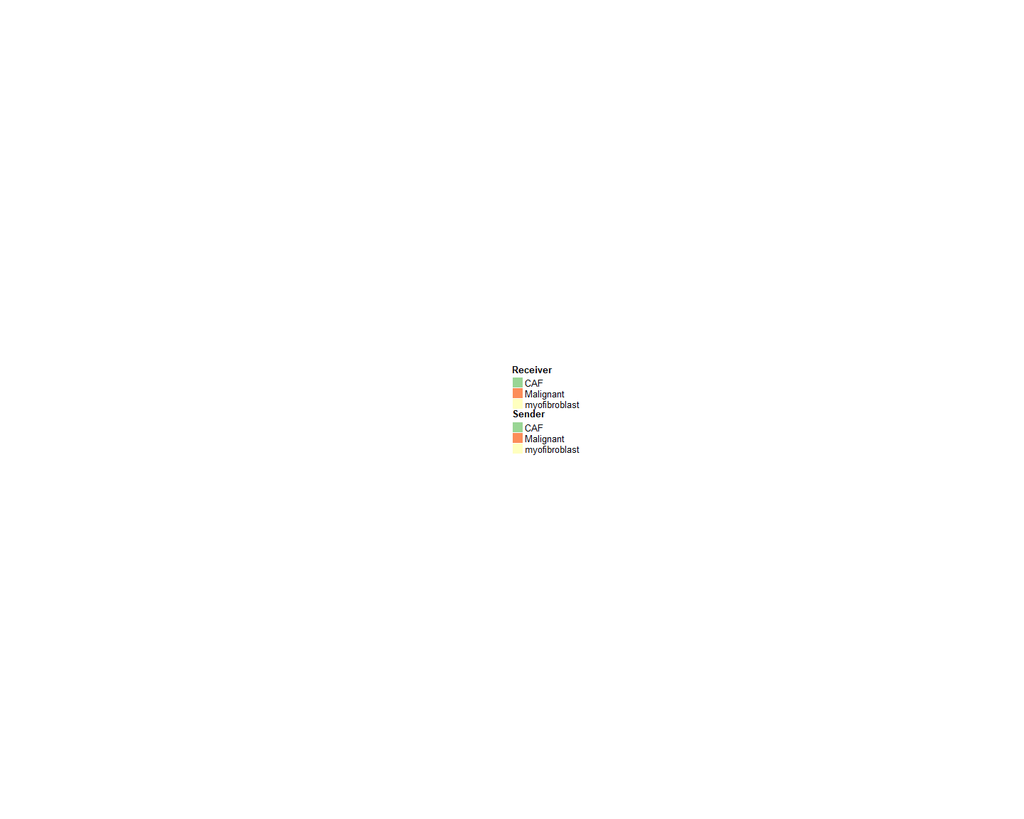

## Visualization of scaled_LR_prod per sample

Now we will visualize per sample the scaled product of ligand and receptor expression. Samples that were left out of the DE analysis are indicated with a smaller dot (this helps to indicate the samples that did not contribute to the calculation of the logFC, and thus not contributed to the final prioritization)

We will now check the top75 interactions specific for the pEMT high group

```r
group_oi = "High"
```

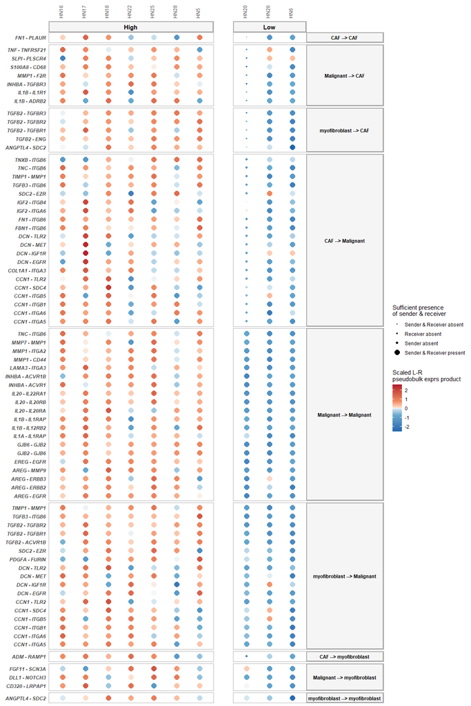

```r
# prioritized_tbl_oi = multinichenet_output$prioritization_tables$group_prioritization_tbl %>%
#   distinct(id, sender, receiver, lr_interaction, group, ligand_receptor_lfc_avg, activity_scaled, fraction_expressing_ligand_receptor,  prioritization_score) %>%
#   filter(fraction_expressing_ligand_receptor > 0) %>%
#   filter(group == group_oi) %>% group_by(group) %>% top_n(75, prioritization_score)

prioritized_tbl_oi_high75 = get_top_n_lr_pairs(prioritization_tables, 75, groups_oi = group_oi)

plot_oi = make_sample_lr_prod_plots(multinichenet_output$prioritization_tables, prioritized_tbl_oi_high75)
plot_oi
```

Next to these LR expression products, we can also plot the NicheNet ligand activities of the ligand in the receiver.

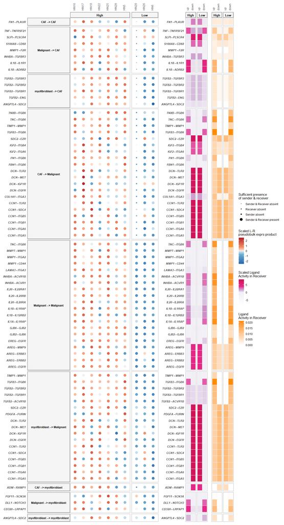

```r
# prioritized_tbl_oi = multinichenet_output$prioritization_tables$group_prioritization_tbl %>%
#   distinct(id, sender, receiver, lr_interaction, group, ligand_receptor_lfc_avg, activity_scaled, fraction_expressing_ligand_receptor,  prioritization_score) %>%
#   filter(fraction_expressing_ligand_receptor > 0) %>%
#   filter(group == group_oi) %>% group_by(group) %>% top_n(150, prioritization_score)

plot_oi = make_sample_lr_prod_activity_plots(multinichenet_output$prioritization_tables, prioritized_tbl_oi_high75, widths = c(4,1,1))
plot_oi
```

## Visualization of expression-logFC per group and ligand activity

Next type of plots will show the logFC of LR pairs across all sender-receiver pairs that are selected, and add the ligand activity next to it.

```r
receiver_oi = "Malignant"
group_oi = "High"
```

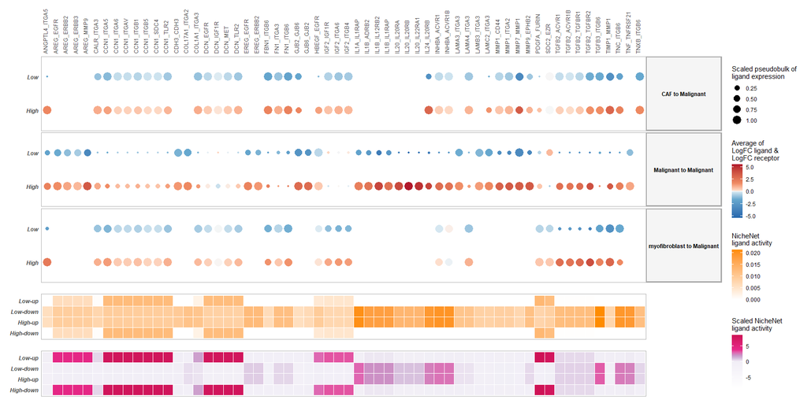

```r
# prioritized_tbl_oi = multinichenet_output$prioritization_tables$group_prioritization_tbl %>%
#   filter(fraction_ligand_group > fraction_cutoff & fraction_receptor_group > fraction_cutoff) %>%
#   distinct(id, sender, receiver, lr_interaction, group, ligand_receptor_lfc_avg, activity_scaled, fraction_ligand_group, fraction_expressing_ligand_receptor, scaled_avg_exprs_ligand, prioritization_score) %>%
#   filter(fraction_expressing_ligand_receptor > 0) %>%
#   filter(group == group_oi & receiver == receiver_oi) %>% top_n(75, prioritization_score)

prioritized_tbl_oi_high75 = get_top_n_lr_pairs(prioritization_tables, 75, groups_oi = group_oi, receivers_oi = receiver_oi)


plot_oi = make_group_lfc_exprs_activity_plot(multinichenet_output$prioritization_tables, prioritized_tbl_oi_high75, receiver_oi, heights = c(5,1,1))
plot_oi
```